# RM-ANOVA for coevolution with a seed bank - Decomposed data

## Population density data

I have previously consolidated all the data on population density collected for this experiment. This includes:

| Population | What it is | Method of measurement |
| --- | --- | --- |
| spore / mL | host spore density | flow-cytometry: low SYBR population |
| veg / mL | host vegetative cell density | flow-cytometry: high SYBR population |
| cell /mL | total host cell density (spore+veg) | flow-cytometry |
| phage/ mL | total SPO1 phage density (free phage) | qPCR (SYBR) with phage specific primers and lysate serial dilution as standard |

In the first few days of the experiment cell numbers dropped below detection limit in 2 of 3 SNO lines. Missing data cannot be analyzed in RM-ANOVA. I will assign these points the detection limit values.

Points with missing data:

```r
d%>%
  filter(cell.ml<10)
```

| culture | line | Time | seed.bank | phage.ml | spore.ml | veg.ml | cell.ml |
| --- | --- | --- | --- | --- | --- | --- | --- |
| SNO | L2 | 2.5 | none | 531673865 | 1 | 1 | 2 |
| SNO | L3 | 2.5 | none | 697684098 | 1 | 1 | 2 |
| SNO | L2 | 3.0 | none | 3627628662 | 1 | 1 | 2 |

**Flow-cytometry detection limit**

The flow cytometer stop conditions were either $50\mu L$ or 50,000 events, whatever came first.  
In addition, to account for false asignments by noise I required that a gated population have at least 100 events to be taken into account. So the minimal detected population would have 100 cells in $50\mu L$ of analyzed liquid. At this poimt of the experiment we were analyzing x100 diluted samples.

```r
detection.limit <- 100 * (1000/50) * 100
```

## I will use $1X10^5$, half the detection limit dor missing value points

```r
d <- d%>%
  mutate(cell.ml=if_else(cell.ml>10, cell.ml,detection.limit/2))
```

I will re-run the RM-ANOVA analysis on the data decomposed to remove seasona (transfer) fluctuations.

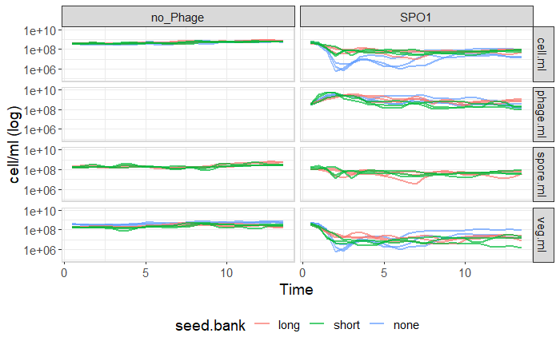

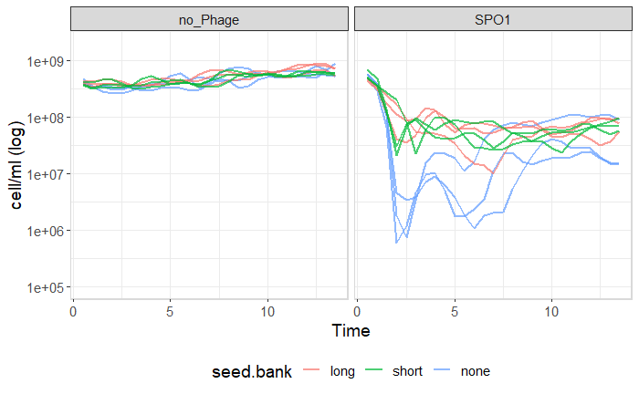

```r
d.decomp.w%>%
    ggplot(aes(x=Time, y=cell.ml))+
      geom_line(aes(group=flask,color=seed.bank), size=1, alpha=0.7)+
      facet_wrap(~phage)+
      theme_bw()+
      panel_border()+
      scale_y_log10()+
      theme(legend.position = "bottom",
            text=element_text(size=14))+
      ylab("cell/ml (log)")+
      coord_cartesian(ylim = c(1e5, 2e9))
```

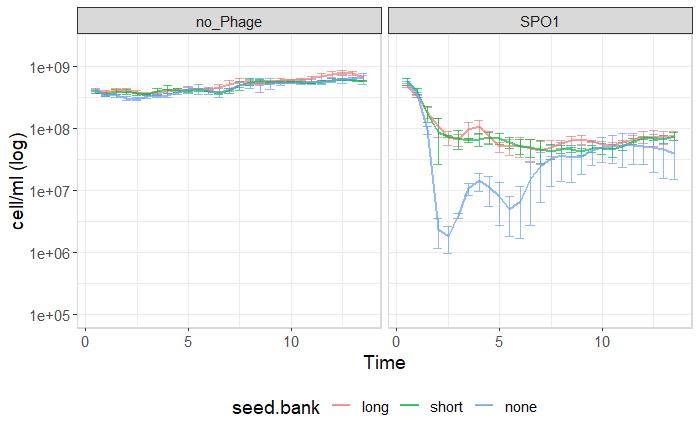

```r
# plot total cells of  data
d.decomp.w%>%
  group_by(phage,seed.bank,Time)%>%
  summarise(n=n(),sd=sd(cell.ml), cell.ml=mean(cell.ml), sem=sd/sqrt(n))%>%
    ggplot(aes(x=Time, y=cell.ml))+
  geom_errorbar(aes(ymin=cell.ml-sem,ymax=cell.ml+sem,color=seed.bank), alpha=0.7)+
      geom_line(aes(color=seed.bank), size=1, alpha=0.7)+
      facet_wrap(~phage)+
      theme_bw()+
      panel_border()+
      scale_y_log10()+
      theme(legend.position = "bottom",
            text=element_text(size=14))+
      ylab("cell/ml (log)")+
      coord_cartesian(ylim = c(1e5, 2e9))
```

# Adjusting variable types for lme

In the lme models I will be using the fixd effects need to be secified as factore, in this experiment these ar: *Phage, seed.bank and time*. However for the autocorrelation specification time needs to be specified as an integer. To fulfill both requirements I will use for the time unit the experimental day rather than transfer, since we measured onc a day but twice per transfer. This will be simplty *time x 2*. I will then make fom that a separate varible which will be the factor of the time.

```r
d.4stat <-
  d.decomp.w%>%
  # remove setup data
  filter(Time>=0)%>%
  #make time an integer for correlation structure
  # by converting to days as time unit
  mutate(Time=as.integer(2*Time))%>%
  # for the lme model all fixed effects need to be factors
  mutate(time.fct=as.factor(Time))%>%
  mutate(seed.bank=as.factor(seed.bank))%>%
  mutate(phage=as.factor(phage))
```

## Model selection

### ARMA covariance

This is a combined auto-regeressive model, AR(p) and moving average model, MA(q). I here take a model selection approach to choose these parameters (lowest AIC).

| p | q | aic |
| --- | --- | --- |
| 5 | 2 | 12466.87 |
| 6 | 2 | 12468.31 |
| 2 | 2 | 12470.22 |
| 3 | 2 | 12473.29 |
| 4 | 2 | 12473.97 |
| 6 | 1 | 12486.50 |
| 5 | 1 | 12492.10 |
| 3 | 1 | 12500.40 |
| 4 | 1 | 12500.93 |
| 2 | 1 | 12521.90 |

[output cut: 10 more lines]

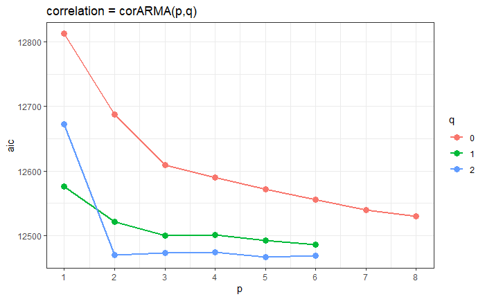

```r
pq.aic%>%arrange(aic)


pq.aic%>%
  mutate(q=as.character(q))%>%
  ggplot(aes(p,aic))+
  geom_line(aes(color=q),size=1)+
  geom_point(aes(color=q),size=3)+
  theme_bw()+
  scale_x_continuous(breaks = 1:10)+
  ggtitle("correlation = corARMA(p,q)")
```

I will test the best 5 models against AR1,

### compare AR1 with ARMA

|  | Model | df | AIC | BIC | logLik | Test | L.Ratio | p-value |
| --- | --- | --- | --- | --- | --- | --- | --- | --- |
| l.rm[[aic.l[6]]] | 1 | 165 | 12812.86 | 13436.68 | -6241.429 |  |  |  |
| l.rm[[aic.l[5]]] | 2 | 170 | 12473.97 | 13116.70 | -6066.985 | 1 vs 2 | 348.8878 | <.0001 |
| l.rm[[aic.l[4]]] | 3 | 169 | 12473.29 | 13112.23 | -6067.643 | 2 vs 3 | 1.3165 | 0.2512 |
| l.rm[[aic.l[3]]] | 4 | 168 | 12470.22 | 13105.39 | -6067.111 | 3 vs 4 | 1.0637 | 0.3024 |
| l.rm[[aic.l[2]]] | 5 | 172 | 12468.31 | 13118.60 | -6062.157 | 4 vs 5 | 9.9085 | 0.0420 |
| l.rm[[aic.l[1]]] | 6 | 171 | 12466.87 | 13113.38 | -6062.436 | 5 vs 6 | 0.5592 | 0.4546 |

```r
#display best model results
tmp <- summary(l.rm[[aic.l[6]]])
tmp$call
```

```
lme.formula(fixed = cell.ml ~ phage * seed.bank * time.fct, data = .,
    random = ~1 | flask, correlation = corAR1(form = ~Time |
        flask))
```

```r
  anova.lme(l.rm[[aic.l[6]]])
```

|  | numDF | denDF | F-value | p-value |
| --- | --- | --- | --- | --- |
| (Intercept) | 1 | 312 | 1758.3398 | <.0001 |
| phage | 1 | 12 | 620.6678 | <.0001 |
| seed.bank | 2 | 12 | 2.0011 | 0.1778 |
| time.fct | 26 | 312 | 12.6610 | <.0001 |
| phage:seed.bank | 2 | 12 | 1.2660 | 0.3171 |
| phage:time.fct | 26 | 312 | 15.3636 | <.0001 |
| seed.bank:time.fct | 52 | 312 | 0.8189 | 0.8075 |
| phage:seed.bank:time.fct | 52 | 312 | 0.6542 | 0.9678 |

The model coAR1 was chosen. **Phage and Time are significant as main effect and their interaction as well. Seed bank is mpt signifcant**

How sensetive would the result be to model selected?

```r
tmp <- map(l.rm, anova.lme)
tmp1 <- map(l.rm, getCall)

for(i in 1:6){
  print(tmp1[[i]])
  if(i<6) print(paste("p=",pq.best$p[i],"q=",pq.best$q[i]))

  print(tmp[[i]])
}
```

```
lme.formula(fixed = cell.ml ~ phage * seed.bank * time.fct, data = .,
    random = ~1 | flask, correlation = corARMA(form = ~Time |
        flask, p = pq.best$p[i], q = pq.best$q[i]))
[1] "p= 5 q= 2"
```

|  | numDF | denDF | F-value | p-value |
| --- | --- | --- | --- | --- |
| (Intercept) | 1 | 312 | 2381.6381 | <.0001 |
| phage | 1 | 12 | 952.8126 | <.0001 |
| seed.bank | 2 | 12 | 3.6517 | 0.0577 |
| time.fct | 26 | 312 | 14.1208 | <.0001 |
| phage:seed.bank | 2 | 12 | 1.4443 | 0.2741 |
| phage:time.fct | 26 | 312 | 16.1737 | <.0001 |
| seed.bank:time.fct | 52 | 312 | 1.0336 | 0.4181 |
| phage:seed.bank:time.fct | 52 | 312 | 1.0081 | 0.4648 |

```
lme.formula(fixed = cell.ml ~ phage * seed.bank * time.fct, data = .,
    random = ~1 | flask, correlation = corARMA(form = ~Time |
        flask, p = pq.best$p[i], q = pq.best$q[i]))
[1] "p= 6 q= 2"
```

|  | numDF | denDF | F-value | p-value |
| --- | --- | --- | --- | --- |
| (Intercept) | 1 | 312 | 2513.0119 | <.0001 |
| phage | 1 | 12 | 1017.4907 | <.0001 |
| seed.bank | 2 | 12 | 3.8544 | 0.0509 |
| time.fct | 26 | 312 | 13.9371 | <.0001 |
| phage:seed.bank | 2 | 12 | 1.4866 | 0.2650 |
| phage:time.fct | 26 | 312 | 16.3233 | <.0001 |
| seed.bank:time.fct | 52 | 312 | 1.0556 | 0.3793 |
| phage:seed.bank:time.fct | 52 | 312 | 1.0318 | 0.4213 |

```
lme.formula(fixed = cell.ml ~ phage * seed.bank * time.fct, data = .,
    random = ~1 | flask, correlation = corARMA(form = ~Time |
        flask, p = pq.best$p[i], q = pq.best$q[i]))
[1] "p= 2 q= 2"
```

|  | numDF | denDF | F-value | p-value |
| --- | --- | --- | --- | --- |
| (Intercept) | 1 | 312 | 2339.1828 | <.0001 |
| phage | 1 | 12 | 1011.4782 | <.0001 |
| seed.bank | 2 | 12 | 3.7246 | 0.0552 |
| time.fct | 26 | 312 | 13.5986 | <.0001 |
| phage:seed.bank | 2 | 12 | 1.2619 | 0.3181 |
| phage:time.fct | 26 | 312 | 18.1025 | <.0001 |
| seed.bank:time.fct | 52 | 312 | 0.9710 | 0.5349 |
| phage:seed.bank:time.fct | 52 | 312 | 0.9109 | 0.6497 |

```
lme.formula(fixed = cell.ml ~ phage * seed.bank * time.fct, data = .,
    random = ~1 | flask, correlation = corARMA(form = ~Time |
        flask, p = pq.best$p[i], q = pq.best$q[i]))
[1] "p= 3 q= 2"
```

|  | numDF | denDF | F-value | p-value |
| --- | --- | --- | --- | --- |
| (Intercept) | 1 | 312 | 3300.014 | <.0001 |
| phage | 1 | 12 | 1412.690 | <.0001 |
| seed.bank | 2 | 12 | 5.108 | 0.0248 |
| time.fct | 26 | 312 | 12.773 | <.0001 |
| phage:seed.bank | 2 | 12 | 1.773 | 0.2115 |
| phage:time.fct | 26 | 312 | 16.996 | <.0001 |
| seed.bank:time.fct | 52 | 312 | 0.954 | 0.5677 |
| phage:seed.bank:time.fct | 52 | 312 | 0.900 | 0.6701 |

```
lme.formula(fixed = cell.ml ~ phage * seed.bank * time.fct, data = .,
    random = ~1 | flask, correlation = corARMA(form = ~Time |
        flask, p = pq.best$p[i], q = pq.best$q[i]))
[1] "p= 4 q= 2"
```

|  | numDF | denDF | F-value | p-value |
| --- | --- | --- | --- | --- |
| (Intercept) | 1 | 312 | 2363.3381 | <.0001 |
| phage | 1 | 12 | 1021.6602 | <.0001 |
| seed.bank | 2 | 12 | 3.7636 | 0.0539 |
| time.fct | 26 | 312 | 13.5690 | <.0001 |
| phage:seed.bank | 2 | 12 | 1.2760 | 0.3144 |
| phage:time.fct | 26 | 312 | 18.0384 | <.0001 |
| seed.bank:time.fct | 52 | 312 | 0.9713 | 0.5343 |
| phage:seed.bank:time.fct | 52 | 312 | 0.9187 | 0.6350 |

```
lme.formula(fixed = cell.ml ~ phage * seed.bank * time.fct, data = .,
    random = ~1 | flask, correlation = corAR1(form = ~Time |
        flask))
```

|  | numDF | denDF | F-value | p-value |
| --- | --- | --- | --- | --- |
| (Intercept) | 1 | 312 | 1758.3398 | <.0001 |
| phage | 1 | 12 | 620.6678 | <.0001 |
| seed.bank | 2 | 12 | 2.0011 | 0.1778 |
| time.fct | 26 | 312 | 12.6610 | <.0001 |
| phage:seed.bank | 2 | 12 | 1.2660 | 0.3171 |
| phage:time.fct | 26 | 312 | 15.3636 | <.0001 |
| seed.bank:time.fct | 52 | 312 | 0.8189 | 0.8075 |
| phage:seed.bank:time.fct | 52 | 312 | 0.6542 | 0.9678 |

All models show the same story:  
* The interaction of interaction between phage and time is significant in influencing cell density.

=================

# Host density by host

=================

I will repeat the same anlysis but will treat the seed-bank as a 2-level factor: with (WT host) or without ($\Delta$spoIIE) a seed bank.

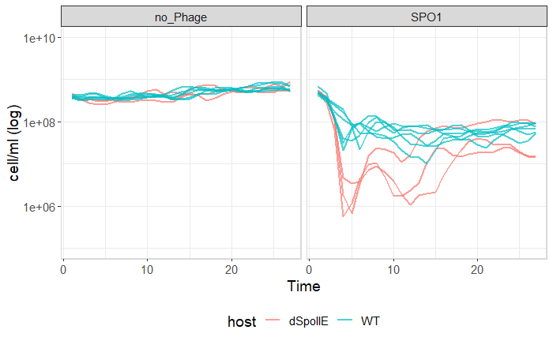

```r
# plot raw data
d.4stat%>%
    ggplot(aes(x=Time, y=cell.ml))+
      geom_line(aes(group=flask,color=host), size=1, alpha=0.7)+
      facet_grid(.~phage)+
      theme_bw()+
      panel_border()+
      scale_y_log10()+
      theme(legend.position = "bottom",
            text=element_text(size=14))+
      ylab("cell/ml (log)")+
      coord_cartesian(ylim = c(1e5, 1e10))
```

## Model selection

### ARMA covariance

This is a combined auto-regeressive model, AR(p) and moving average model, MA(q). I here take a model selection approach to choose these parameters (lowest AIC).

[output not shown]

[output cut: 10 more lines]

[figure not shown]

```r
pq.aic%>%arrange(aic)


pq.aic%>%
  mutate(q=as.character(q))%>%
  ggplot(aes(p,aic))+
  geom_line(aes(color=q),size=1)+
  geom_point(aes(color=q),size=3)+
  theme_bw()+
  scale_x_continuous(breaks = 1:10)+
  ggtitle("correlation = corARMA(p,q)")
```

I will test the best 5 models against AR1,

### compare AR1 with ARMA

```r
l.rm <- list()

pq.best <- pq.aic%>%
  slice_min( order_by=aic,n=5)

for (i in 1:nrow(pq.best)){
  l.rm[[i]] <-
    d.4stat%>%
    # looking only at total cells (cell.ml)
    lme(cell.ml ~ phage * host * time.fct , random = ~1|flask,
            correlation = corARMA(form = ~ Time | flask,
                                  p=pq.best$p[i],q=pq.best$q[i]),
            data = .)

}


# add corAR1 to list
l.rm[[i+1]] <-
  d.4stat%>%
  # looking only at total cells (cell.ml)
    lme(cell.ml ~ phage * host * time.fct , random = ~1|flask,
            correlation = corAR1(form = ~ Time | flask),
            data = .)


# get list order by AIC
aic.l <- sapply(l.rm,AIC)%>%
  sort.list()


# compare models by AIC order
anova.lme(l.rm[[aic.l[6]]],
          l.rm[[aic.l[5]]],
          l.rm[[aic.l[4]]],
          l.rm[[aic.l[3]]],
          l.rm[[aic.l[2]]],
          l.rm[[aic.l[1]]])
```

|  | Model | df | AIC | BIC | logLik | Test | L.Ratio | p-value |
| --- | --- | --- | --- | --- | --- | --- | --- | --- |
| l.rm[[aic.l[6]]] | 1 | 111 | 14722.39 | 15159.16 | -7250.194 |  |  |  |
| l.rm[[aic.l[5]]] | 2 | 116 | 14325.94 | 14782.39 | -7046.972 | 1 vs 2 | 406.4434 | <.0001 |
| l.rm[[aic.l[4]]] | 3 | 115 | 14324.30 | 14776.82 | -7047.152 | 2 vs 3 | 0.3587 | 0.5492 |
| l.rm[[aic.l[3]]] | 4 | 118 | 14323.89 | 14788.21 | -7043.945 | 3 vs 4 | 6.4125 | 0.0932 |
| l.rm[[aic.l[2]]] | 5 | 114 | 14322.30 | 14770.88 | -7047.152 | 4 vs 5 | 6.4125 | 0.1704 |
| l.rm[[aic.l[1]]] | 6 | 117 | 14322.23 | 14782.62 | -7044.117 | 5 vs 6 | 6.0688 | 0.1083 |

```r
#display best model results
getCall(l.rm[[aic.l[6]]])
  anova.lme(l.rm[[aic.l[6]]])
```

[output not shown]

The model wirth coAR1 was chosen. **Phage and Time are significant as main effect and their interaction as well. Seed bank is mpt signifcant**

How sensetive would the result be to model selected?

```r
tmp <- map(l.rm, anova.lme)
tmp1 <- map(l.rm, getCall)

for(i in 1:6){
  print(tmp1[[i]])
  if(i<6) print(paste("p=",pq.best$p[i],"q=",pq.best$q[i]))

  print(tmp[[i]])
}
```

```
lme.formula(fixed = cell.ml ~ phage * host * time.fct, data = .,
    random = ~1 | flask, correlation = corARMA(form = ~Time |
        flask, p = pq.best$p[i], q = pq.best$q[i]))
[1] "p= 5 q= 2"
```

|  | numDF | denDF | F-value | p-value |
| --- | --- | --- | --- | --- |
| (Intercept) | 1 | 364 | 2077.5020 | <.0001 |
| phage | 1 | 14 | 825.4642 | <.0001 |
| host | 1 | 14 | 3.9058 | 0.0682 |
| time.fct | 26 | 364 | 13.8539 | <.0001 |
| phage:host | 1 | 14 | 0.0233 | 0.8809 |
| phage:time.fct | 26 | 364 | 15.9852 | <.0001 |
| host:time.fct | 26 | 364 | 1.3204 | 0.1382 |
| phage:host:time.fct | 26 | 364 | 1.1243 | 0.3096 |

```
lme.formula(fixed = cell.ml ~ phage * host * time.fct, data = .,
    random = ~1 | flask, correlation = corARMA(form = ~Time |
        flask, p = pq.best$p[i], q = pq.best$q[i]))
[1] "p= 6 q= 2"
```

|  | numDF | denDF | F-value | p-value |
| --- | --- | --- | --- | --- |
| (Intercept) | 1 | 364 | 2049.5786 | <.0001 |
| phage | 1 | 14 | 829.1529 | <.0001 |
| host | 1 | 14 | 3.9135 | 0.0679 |
| time.fct | 26 | 364 | 13.8108 | <.0001 |
| phage:host | 1 | 14 | 0.0235 | 0.8803 |
| phage:time.fct | 26 | 364 | 16.3982 | <.0001 |
| host:time.fct | 26 | 364 | 1.3391 | 0.1269 |
| phage:host:time.fct | 26 | 364 | 1.1574 | 0.2737 |

```
lme.formula(fixed = cell.ml ~ phage * host * time.fct, data = .,
    random = ~1 | flask, correlation = corARMA(form = ~Time |
        flask, p = pq.best$p[i], q = pq.best$q[i]))
[1] "p= 2 q= 2"
```

|  | numDF | denDF | F-value | p-value |
| --- | --- | --- | --- | --- |
| (Intercept) | 1 | 364 | 1940.8368 | <.0001 |
| phage | 1 | 14 | 836.7870 | <.0001 |
| host | 1 | 14 | 4.0746 | 0.0631 |
| time.fct | 26 | 364 | 13.7486 | <.0001 |
| phage:host | 1 | 14 | 0.0166 | 0.8993 |
| phage:time.fct | 26 | 364 | 18.3624 | <.0001 |
| host:time.fct | 26 | 364 | 1.2759 | 0.1686 |
| phage:host:time.fct | 26 | 364 | 1.0831 | 0.3581 |

```
lme.formula(fixed = cell.ml ~ phage * host * time.fct, data = .,
    random = ~1 | flask, correlation = corARMA(form = ~Time |
        flask, p = pq.best$p[i], q = pq.best$q[i]))
[1] "p= 3 q= 2"
```

|  | numDF | denDF | F-value | p-value |
| --- | --- | --- | --- | --- |
| (Intercept) | 1 | 364 | 1940.8210 | <.0001 |
| phage | 1 | 14 | 836.7920 | <.0001 |
| host | 1 | 14 | 4.0747 | 0.0631 |
| time.fct | 26 | 364 | 13.7487 | <.0001 |
| phage:host | 1 | 14 | 0.0166 | 0.8993 |
| phage:time.fct | 26 | 364 | 18.3629 | <.0001 |
| host:time.fct | 26 | 364 | 1.2759 | 0.1686 |
| phage:host:time.fct | 26 | 364 | 1.0831 | 0.3581 |

```
lme.formula(fixed = cell.ml ~ phage * host * time.fct, data = .,
    random = ~1 | flask, correlation = corARMA(form = ~Time |
        flask, p = pq.best$p[i], q = pq.best$q[i]))
[1] "p= 4 q= 2"
```

|  | numDF | denDF | F-value | p-value |
| --- | --- | --- | --- | --- |
| (Intercept) | 1 | 364 | 1972.7049 | <.0001 |
| phage | 1 | 14 | 839.2087 | <.0001 |
| host | 1 | 14 | 4.0342 | 0.0643 |
| time.fct | 26 | 364 | 13.6497 | <.0001 |
| phage:host | 1 | 14 | 0.0202 | 0.8891 |
| phage:time.fct | 26 | 364 | 17.8082 | <.0001 |
| host:time.fct | 26 | 364 | 1.2869 | 0.1606 |
| phage:host:time.fct | 26 | 364 | 1.0973 | 0.3409 |

```
lme.formula(fixed = cell.ml ~ phage * host * time.fct, data = .,
    random = ~1 | flask, correlation = corAR1(form = ~Time |
        flask))
```

|  | numDF | denDF | F-value | p-value |
| --- | --- | --- | --- | --- |
| (Intercept) | 1 | 364 | 1629.3636 | <.0001 |
| phage | 1 | 14 | 560.7985 | <.0001 |
| host | 1 | 14 | 2.3620 | 0.1466 |
| time.fct | 26 | 364 | 12.7928 | <.0001 |
| phage:host | 1 | 14 | 0.0128 | 0.9115 |
| phage:time.fct | 26 | 364 | 15.2081 | <.0001 |
| host:time.fct | 26 | 364 | 1.0097 | 0.4536 |
| phage:host:time.fct | 26 | 364 | 0.4804 | 0.9866 |

All models show the same story: as sbove.

=================

# phage density

=================

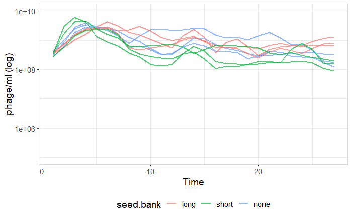

Here I will remove time 0, the input phage

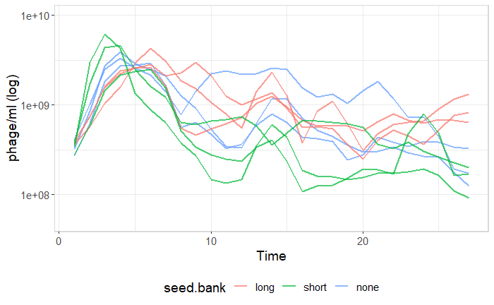

```r
d.4stat%>%
  filter(phage=="SPO1")%>%
  filter(Time!=0)%>%
    ggplot(aes(x=Time, y=phage.ml))+
      geom_line(aes(group=flask,color=seed.bank), size=1, alpha=0.7)+
      theme_bw()+
      panel_border()+
      scale_y_log10()+
      theme(legend.position = "bottom",
            text=element_text(size=14))+
      ylab("phage/ml (log)")+
      coord_cartesian(ylim = c(5e7, 1e10))
```

## Model selection

### ARMA covariance

This is a combined auto-regeressive model, AR(p) and moving average model, MA(q). I here take a model selection approach to choose these parameters (lowest AIC).

```r
# initalise empty table
pq.aic <- tibble(p=1, q=1,aic=1)%>%
  filter(p>1)

# Playing around with p&q I found the space in which the model convergence is limited
for(Q in c(0:2)){
  for (P in c(1:(10-2*Q))){

        #this fllowing combination does not work: "iteration limit reached without convergence"
    # if(P>=6 & Q==2) next

    cur.model <-
        d.4stat%>%
      filter(Time!=0)%>%
      filter(phage=="SPO1")%>%
  # looking only at total cells (cell.ml)
    lme(phage.ml ~ seed.bank * time.fct , random = ~1|flask,
            correlation = corARMA(form = ~ Time | flask, p=P,q=Q),
            data = .)

    pq.aic <-
      tibble(p=P, q=Q,aic=AIC(cur.model))%>%
      bind_rows(pq.aic,.)

  }
}

pq.aic%>%arrange(aic)
```

| p | q | aic |
| --- | --- | --- |
| 2 | 2 | 6972.915 |
| 3 | 2 | 6974.330 |
| 4 | 2 | 6976.269 |
| 5 | 2 | 6977.472 |
| 7 | 1 | 6977.810 |
| 5 | 1 | 6979.204 |
| 6 | 2 | 6979.219 |
| 8 | 1 | 6979.386 |
| 6 | 1 | 6979.618 |
| 4 | 1 | 6981.948 |

[output cut: 14 more lines]

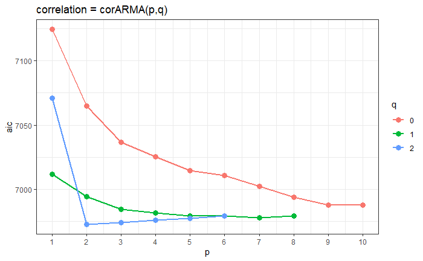

```r
pq.aic%>%
  mutate(q=as.character(q))%>%
  ggplot(aes(p,aic))+
  geom_line(aes(color=q),size=1)+
  geom_point(aes(color=q),size=3)+
  theme_bw()+
  scale_x_continuous(breaks = 1:10)+
  ggtitle("correlation = corARMA(p,q)")
```

```r
NA
NA
```

I will test the best 5 models against AR1,

### compare AR1 with ARMA

```r
l.rm <- list()

pq.best <- pq.aic%>%
  slice_min( order_by=aic,n=5)

for (i in 1:nrow(pq.best)){
  l.rm[[i]] <-
    d.4stat%>%
    filter(Time!=0)%>%
    filter(phage=="SPO1")%>%
  # looking only at phages (phage.ml)
    lme(phage.ml ~ seed.bank * time.fct , random = ~1|flask,
            correlation = corARMA(form = ~ 1 | flask,
                                  p=pq.best$p[i],q=pq.best$q[i]),
            data = .)

}


# add corAR1 to list
l.rm[[i+1]] <-
  d.4stat%>%
  filter(phage=="SPO1")%>%
  filter(Time!=0)%>%
 # looking only at phages (phage.ml)
    lme(phage.ml ~ seed.bank * time.fct , random = ~1|flask,
            correlation = corAR1(form = ~ 1 | flask),
            data = .)


# get list order by AIC
aic.l <- sapply(l.rm,AIC)%>%
  sort.list()


# compare models by AIC order
anova.lme(l.rm[[aic.l[6]]],
          l.rm[[aic.l[5]]],
          l.rm[[aic.l[4]]],
          l.rm[[aic.l[3]]],
          l.rm[[aic.l[2]]],
          l.rm[[aic.l[1]]])
```

|  | Model | df | AIC | BIC | logLik | Test | L.Ratio | p-value |
| --- | --- | --- | --- | --- | --- | --- | --- | --- |
| l.rm[[aic.l[6]]] | 1 | 84 | 7124.337 | 7383.695 | -3478.168 |  |  |  |
| l.rm[[aic.l[5]]] | 2 | 91 | 6977.810 | 7258.782 | -3397.905 | 1 vs 2 | 160.52663 | <.0001 |
| l.rm[[aic.l[4]]] | 3 | 90 | 6977.472 | 7255.356 | -3398.736 | 2 vs 3 | 1.66166 | 0.1974 |
| l.rm[[aic.l[3]]] | 4 | 89 | 6976.269 | 7251.066 | -3399.135 | 3 vs 4 | 0.79754 | 0.3718 |
| l.rm[[aic.l[2]]] | 5 | 88 | 6974.330 | 7246.039 | -3399.165 | 4 vs 5 | 0.06097 | 0.8050 |
| l.rm[[aic.l[1]]] | 6 | 87 | 6972.915 | 7241.536 | -3399.458 | 5 vs 6 | 0.58500 | 0.4444 |

```r
#display best model results
getCall(l.rm[[aic.l[6]]])
```

```
lme.formula(fixed = phage.ml ~ seed.bank * time.fct, data = .,
    random = ~1 | flask, correlation = corAR1(form = ~1 | flask))
```

```r
  anova(l.rm[[aic.l[6]]])
```

|  | numDF | denDF | F-value | p-value |
| --- | --- | --- | --- | --- |
| (Intercept) | 1 | 156 | 123.92070 | <.0001 |
| seed.bank | 2 | 6 | 1.66749 | 0.2655 |
| time.fct | 26 | 156 | 11.19476 | <.0001 |
| seed.bank:time.fct | 52 | 156 | 2.35820 | <.0001 |

How sensetive would the result be to model selected?

```r
tmp <- map(l.rm, anova.lme)
tmp1 <- map(l.rm, getCall)

for(i in 1:6){
  print(tmp1[[i]])
  if(i<6) print(paste("p=",pq.best$p[i],"q=",pq.best$q[i]))

  print(tmp[[i]])
}
```

```
lme.formula(fixed = phage.ml ~ seed.bank * time.fct, data = .,
    random = ~1 | flask, correlation = corARMA(form = ~1 | flask,
        p = pq.best$p[i], q = pq.best$q[i]))
[1] "p= 2 q= 2"
```

|  | numDF | denDF | F-value | p-value |
| --- | --- | --- | --- | --- |
| (Intercept) | 1 | 156 | 129.43696 | <.0001 |
| seed.bank | 2 | 6 | 1.59866 | 0.2776 |
| time.fct | 26 | 156 | 16.17110 | <.0001 |
| seed.bank:time.fct | 52 | 156 | 2.28386 | <.0001 |

```
lme.formula(fixed = phage.ml ~ seed.bank * time.fct, data = .,
    random = ~1 | flask, correlation = corARMA(form = ~1 | flask,
        p = pq.best$p[i], q = pq.best$q[i]))
[1] "p= 3 q= 2"
```

|  | numDF | denDF | F-value | p-value |
| --- | --- | --- | --- | --- |
| (Intercept) | 1 | 156 | 129.68779 | <.0001 |
| seed.bank | 2 | 6 | 1.56630 | 0.2836 |
| time.fct | 26 | 156 | 16.59909 | <.0001 |
| seed.bank:time.fct | 52 | 156 | 2.28477 | <.0001 |

```
lme.formula(fixed = phage.ml ~ seed.bank * time.fct, data = .,
    random = ~1 | flask, correlation = corARMA(form = ~1 | flask,
        p = pq.best$p[i], q = pq.best$q[i]))
[1] "p= 4 q= 2"
```

|  | numDF | denDF | F-value | p-value |
| --- | --- | --- | --- | --- |
| (Intercept) | 1 | 156 | 128.79279 | <.0001 |
| seed.bank | 2 | 6 | 1.60350 | 0.2768 |
| time.fct | 26 | 156 | 16.64594 | <.0001 |
| seed.bank:time.fct | 52 | 156 | 2.29411 | <.0001 |

```
lme.formula(fixed = phage.ml ~ seed.bank * time.fct, data = .,
    random = ~1 | flask, correlation = corARMA(form = ~1 | flask,
        p = pq.best$p[i], q = pq.best$q[i]))
[1] "p= 5 q= 2"
```

|  | numDF | denDF | F-value | p-value |
| --- | --- | --- | --- | --- |
| (Intercept) | 1 | 156 | 134.66749 | <.0001 |
| seed.bank | 2 | 6 | 1.38348 | 0.3206 |
| time.fct | 26 | 156 | 16.72018 | <.0001 |
| seed.bank:time.fct | 52 | 156 | 2.33484 | <.0001 |

```
lme.formula(fixed = phage.ml ~ seed.bank * time.fct, data = .,
    random = ~1 | flask, correlation = corARMA(form = ~1 | flask,
        p = pq.best$p[i], q = pq.best$q[i]))
[1] "p= 7 q= 1"
```

|  | numDF | denDF | F-value | p-value |
| --- | --- | --- | --- | --- |
| (Intercept) | 1 | 156 | 138.77545 | <.0001 |
| seed.bank | 2 | 6 | 1.16779 | 0.3729 |
| time.fct | 26 | 156 | 16.55803 | <.0001 |
| seed.bank:time.fct | 52 | 156 | 2.30164 | <.0001 |

```
lme.formula(fixed = phage.ml ~ seed.bank * time.fct, data = .,
    random = ~1 | flask, correlation = corAR1(form = ~1 | flask))
```

|  | numDF | denDF | F-value | p-value |
| --- | --- | --- | --- | --- |
| (Intercept) | 1 | 156 | 123.92070 | <.0001 |
| seed.bank | 2 | 6 | 1.66749 | 0.2655 |
| time.fct | 26 | 156 | 11.19476 | <.0001 |
| seed.bank:time.fct | 52 | 156 | 2.35820 | <.0001 |

All models show the same story: Seed bank X time significant for phage.

=================

# spore density

=================

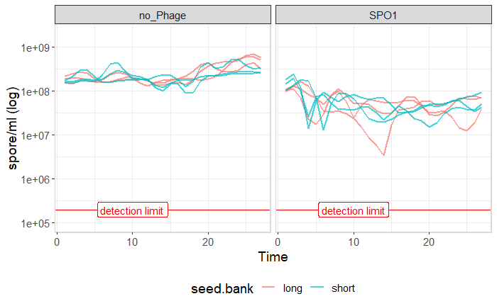

```r
d.4stat%>%
  filter(host=="WT")%>%
       ggplot(aes(x=Time, y=spore.ml))+
      geom_line(aes(group=flask,color=seed.bank), size=1, alpha=0.7)+
  geom_hline(yintercept = detection.limit, color="red")+
  geom_label(label="detection limit", x=10, y=log10(detection.limit), color="red")+
      facet_wrap(~phage)+
      theme_bw()+
      panel_border()+
      scale_y_log10()+
      theme(legend.position = "bottom",
            text=element_text(size=14))+
      ylab("spore/ml (log)")+
      coord_cartesian(ylim = c(1e5, 2e9))
```

All points usable.

## Model selection

### ARMA covariance

This is a combined auto-regeressive model, AR(p) and moving average model, MA(q). I here take a model selection approach to choose these parameters (lowest AIC).

| p | q | aic |
| --- | --- | --- |
| 3 | 2 | 8201.156 |
| 2 | 2 | 8202.715 |
| 4 | 2 | 8202.811 |
| 5 | 2 | 8204.530 |
| 6 | 1 | 8208.790 |
| 7 | 1 | 8210.192 |
| 10 | 0 | 8210.745 |
| 5 | 1 | 8211.314 |
| 8 | 1 | 8212.104 |
| 4 | 1 | 8212.397 |

[output cut: 13 more lines]

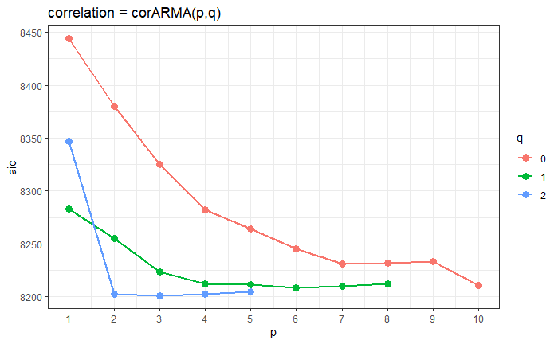

```r
pq.aic%>%arrange(aic)


pq.aic%>%
  mutate(q=as.character(q))%>%
  ggplot(aes(p,aic))+
  geom_line(aes(color=q),size=1)+
  geom_point(aes(color=q),size=3)+
  theme_bw()+
  scale_x_continuous(breaks = 1:10)+
  ggtitle("correlation = corARMA(p,q)")
```

I will test the best 5 models against AR1,

### compare AR1 with ARMA

```r
l.rm <- list()

pq.best <- pq.aic%>%
  slice_min( order_by=aic,n=5)

for (i in 1:nrow(pq.best)){
  l.rm[[i]] <-
        d.4stat%>%
      filter(host=="WT")%>%
  # looking only at total spore (spore.ml)
    lme(spore.ml ~ phage*seed.bank * time.fct , random = ~1|flask,
        correlation = corARMA(form = ~ 1 | flask,
                              p=pq.best$p[i],q=pq.best$q[i]),
            data = .)

}


# add corAR1 to list
l.rm[[i+1]] <-
        d.4stat%>%
      filter(host=="WT")%>%
  # looking only at total spore (spore.ml)
    lme(spore.ml ~ phage*seed.bank * time.fct , random = ~1|flask,
            correlation = corAR1(form = ~ 1 | flask),
            data = .)


# get list order by AIC
aic.l <- sapply(l.rm,AIC)%>%
  sort.list()


# compare models by AIC order
anova.lme(l.rm[[aic.l[6]]],
          l.rm[[aic.l[5]]],
          l.rm[[aic.l[4]]],
          l.rm[[aic.l[3]]],
          l.rm[[aic.l[2]]],
          l.rm[[aic.l[1]]])
```

|  | Model | df | AIC | BIC | logLik | Test | L.Ratio | p-value |
| --- | --- | --- | --- | --- | --- | --- | --- | --- |
| l.rm[[aic.l[6]]] | 1 | 111 | 8443.898 | 8818.553 | -4110.949 |  |  |  |
| l.rm[[aic.l[5]]] | 2 | 117 | 8208.790 | 8603.698 | -3987.395 | 1 vs 2 | 247.10752 | <.0001 |
| l.rm[[aic.l[4]]] | 3 | 117 | 8204.530 | 8599.437 | -3985.265 |  |  |  |
| l.rm[[aic.l[3]]] | 4 | 116 | 8202.811 | 8594.343 | -3985.405 | 3 vs 4 | 0.28105 | 0.5960 |
| l.rm[[aic.l[2]]] | 5 | 114 | 8202.715 | 8587.497 | -3987.357 | 4 vs 5 | 3.90429 | 0.1420 |
| l.rm[[aic.l[1]]] | 6 | 115 | 8201.156 | 8589.313 | -3985.578 | 5 vs 6 | 3.55943 | 0.0592 |

```r
#display best model results
getCall(l.rm[[aic.l[6]]])
```

```
lme.formula(fixed = spore.ml ~ phage * seed.bank * time.fct,
    data = ., random = ~1 | flask, correlation = corAR1(form = ~1 |
        flask))
```

```r
  anova.lme(l.rm[[aic.l[6]]])
```

|  | numDF | denDF | F-value | p-value |
| --- | --- | --- | --- | --- |
| (Intercept) | 1 | 208 | 368.2202 | <.0001 |
| phage | 1 | 8 | 124.0256 | <.0001 |
| seed.bank | 1 | 8 | 1.4955 | 0.2562 |
| time.fct | 26 | 208 | 3.9099 | <.0001 |
| phage:seed.bank | 1 | 8 | 3.1100 | 0.1158 |
| phage:time.fct | 26 | 208 | 3.9828 | <.0001 |
| seed.bank:time.fct | 26 | 208 | 1.5261 | 0.0561 |
| phage:seed.bank:time.fct | 26 | 208 | 1.6883 | 0.0242 |

**There is significant effect of interaction of phage, seed.bank and time on spore population density.**

How sensetive would the result be to model selected?

```r
tmp <- map(l.rm, anova.lme)
tmp1 <- map(l.rm, getCall)

for(i in 1:6){
  print(tmp1[[i]])
  if(i<6) print(paste("p=",pq.best$p[i],"q=",pq.best$q[i]))

  print(tmp[[i]])
}
```

```
lme.formula(fixed = spore.ml ~ phage * seed.bank * time.fct,
    data = ., random = ~1 | flask, correlation = corARMA(form = ~1 |
        flask, p = pq.best$p[i], q = pq.best$q[i]))
[1] "p= 3 q= 2"
```

|  | numDF | denDF | F-value | p-value |
| --- | --- | --- | --- | --- |
| (Intercept) | 1 | 208 | 549.0385 | <.0001 |
| phage | 1 | 8 | 183.4507 | <.0001 |
| seed.bank | 1 | 8 | 1.5842 | 0.2436 |
| time.fct | 26 | 208 | 4.7153 | <.0001 |
| phage:seed.bank | 1 | 8 | 2.7927 | 0.1332 |
| phage:time.fct | 26 | 208 | 5.1200 | <.0001 |
| seed.bank:time.fct | 26 | 208 | 1.4355 | 0.0870 |
| phage:seed.bank:time.fct | 26 | 208 | 1.6328 | 0.0325 |

```
lme.formula(fixed = spore.ml ~ phage * seed.bank * time.fct,
    data = ., random = ~1 | flask, correlation = corARMA(form = ~1 |
        flask, p = pq.best$p[i], q = pq.best$q[i]))
[1] "p= 2 q= 2"
```

|  | numDF | denDF | F-value | p-value |
| --- | --- | --- | --- | --- |
| (Intercept) | 1 | 208 | 675.0401 | <.0001 |
| phage | 1 | 8 | 231.9151 | <.0001 |
| seed.bank | 1 | 8 | 1.6805 | 0.2310 |
| time.fct | 26 | 208 | 4.8353 | <.0001 |
| phage:seed.bank | 1 | 8 | 2.8365 | 0.1306 |
| phage:time.fct | 26 | 208 | 5.3598 | <.0001 |
| seed.bank:time.fct | 26 | 208 | 1.4909 | 0.0667 |
| phage:seed.bank:time.fct | 26 | 208 | 1.7198 | 0.0204 |

```
lme.formula(fixed = spore.ml ~ phage * seed.bank * time.fct,
    data = ., random = ~1 | flask, correlation = corARMA(form = ~1 |
        flask, p = pq.best$p[i], q = pq.best$q[i]))
[1] "p= 4 q= 2"
```

|  | numDF | denDF | F-value | p-value |
| --- | --- | --- | --- | --- |
| (Intercept) | 1 | 208 | 516.0972 | <.0001 |
| phage | 1 | 8 | 170.9308 | <.0001 |
| seed.bank | 1 | 8 | 1.5857 | 0.2434 |
| time.fct | 26 | 208 | 4.7421 | <.0001 |
| phage:seed.bank | 1 | 8 | 2.7691 | 0.1347 |
| phage:time.fct | 26 | 208 | 5.1192 | <.0001 |
| seed.bank:time.fct | 26 | 208 | 1.4265 | 0.0908 |
| phage:seed.bank:time.fct | 26 | 208 | 1.6278 | 0.0333 |

```
lme.formula(fixed = spore.ml ~ phage * seed.bank * time.fct,
    data = ., random = ~1 | flask, correlation = corARMA(form = ~1 |
        flask, p = pq.best$p[i], q = pq.best$q[i]))
[1] "p= 5 q= 2"
```

|  | numDF | denDF | F-value | p-value |
| --- | --- | --- | --- | --- |
| (Intercept) | 1 | 208 | 551.7177 | <.0001 |
| phage | 1 | 8 | 184.0927 | <.0001 |
| seed.bank | 1 | 8 | 1.6243 | 0.2383 |
| time.fct | 26 | 208 | 4.7375 | <.0001 |
| phage:seed.bank | 1 | 8 | 2.8352 | 0.1307 |
| phage:time.fct | 26 | 208 | 5.1120 | <.0001 |
| seed.bank:time.fct | 26 | 208 | 1.4313 | 0.0887 |
| phage:seed.bank:time.fct | 26 | 208 | 1.6097 | 0.0366 |

```
lme.formula(fixed = spore.ml ~ phage * seed.bank * time.fct,
    data = ., random = ~1 | flask, correlation = corARMA(form = ~1 |
        flask, p = pq.best$p[i], q = pq.best$q[i]))
[1] "p= 6 q= 1"
```

|  | numDF | denDF | F-value | p-value |
| --- | --- | --- | --- | --- |
| (Intercept) | 1 | 208 | 684.9176 | <.0001 |
| phage | 1 | 8 | 237.3938 | <.0001 |
| seed.bank | 1 | 8 | 1.7289 | 0.2250 |
| time.fct | 26 | 208 | 4.2086 | <.0001 |
| phage:seed.bank | 1 | 8 | 2.8775 | 0.1283 |
| phage:time.fct | 26 | 208 | 4.7276 | <.0001 |
| seed.bank:time.fct | 26 | 208 | 1.4787 | 0.0708 |
| phage:seed.bank:time.fct | 26 | 208 | 1.6452 | 0.0304 |

```
lme.formula(fixed = spore.ml ~ phage * seed.bank * time.fct,
    data = ., random = ~1 | flask, correlation = corAR1(form = ~1 |
        flask))
```

|  | numDF | denDF | F-value | p-value |
| --- | --- | --- | --- | --- |
| (Intercept) | 1 | 208 | 368.2202 | <.0001 |
| phage | 1 | 8 | 124.0256 | <.0001 |
| seed.bank | 1 | 8 | 1.4955 | 0.2562 |
| time.fct | 26 | 208 | 3.9099 | <.0001 |
| phage:seed.bank | 1 | 8 | 3.1100 | 0.1158 |
| phage:time.fct | 26 | 208 | 3.9828 | <.0001 |
| seed.bank:time.fct | 26 | 208 | 1.5261 | 0.0561 |
| phage:seed.bank:time.fct | 26 | 208 | 1.6883 | 0.0242 |

The phage:seed-bank:time interaction is hovering closely below 0.05, but in all case ur us below it.

=================

# percent spore

=================

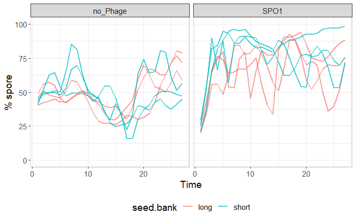

```r
d.4stat <- d.4stat%>%
  mutate(perc.spore=100*spore.ml/cell.ml)

d.4stat%>%
  filter(host=="WT")%>%
    ggplot(aes(x=Time, y=perc.spore))+
    geom_line(aes(group=flask,color=seed.bank), size=1, alpha=0.7)+
    theme_bw()+
    panel_border()+
  facet_wrap(~phage)+
  theme(legend.position = "bottom",
            text=element_text(size=14))+
  ylab("% spore")+
  ylim(0,100)
```

All points usable.

## Model selection

### ARMA covariance

This is a combined auto-regeressive model, AR(p) and moving average model, MA(q). I here take a model selection approach to choose these parameters (lowest AIC).

| p | q | aic |
| --- | --- | --- |
| 1 | 1 | 1798.842 |
| 2 | 1 | 1800.793 |
| 3 | 1 | 1801.736 |
| 2 | 2 | 1802.003 |
| 5 | 0 | 1802.717 |
| 3 | 0 | 1802.880 |
| 4 | 1 | 1803.051 |
| 4 | 0 | 1803.197 |
| 3 | 2 | 1803.340 |
| 5 | 2 | 1804.340 |

[output cut: 9 more lines]

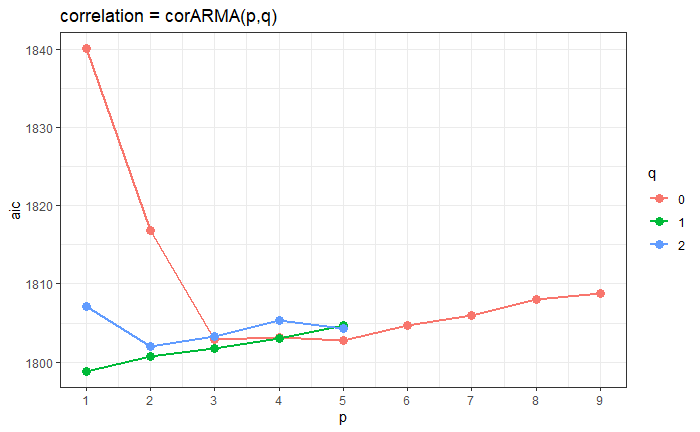

```r
pq.aic%>%arrange(aic)


pq.aic%>%
  mutate(q=as.character(q))%>%
  ggplot(aes(p,aic))+
  geom_line(aes(color=q),size=1)+
  geom_point(aes(color=q),size=3)+
  theme_bw()+
  scale_x_continuous(breaks = 1:10)+
  ggtitle("correlation = corARMA(p,q)")
```

I will test the best 5 models against AR1,

### compare AR1 with ARMA

|  | Model | df | AIC | BIC | logLik | Test | L.Ratio | p-value |
| --- | --- | --- | --- | --- | --- | --- | --- | --- |
| l.rm[[aic.l[6]]] | 1 | 111 | 1840.044 | 2214.700 | -809.0220 |  |  |  |
| l.rm[[aic.l[5]]] | 2 | 115 | 1802.717 | 2190.874 | -786.3585 | 1 vs 2 | 45.32694 | <.0001 |
| l.rm[[aic.l[4]]] | 3 | 114 | 1802.003 | 2186.785 | -787.0016 | 2 vs 3 | 1.28621 | 0.2567 |
| l.rm[[aic.l[3]]] | 4 | 114 | 1801.736 | 2186.517 | -786.8678 |  |  |  |
| l.rm[[aic.l[2]]] | 5 | 113 | 1800.793 | 2182.199 | -787.3963 | 4 vs 5 | 1.05713 | 0.3039 |
| l.rm[[aic.l[1]]] | 6 | 112 | 1798.842 | 2176.873 | -787.4209 | 5 vs 6 | 0.04918 | 0.8245 |

```r
#display best model results
getCall(l.rm[[aic.l[6]]])
```

```
lme.formula(fixed = perc.spore ~ phage * seed.bank * time.fct,
    data = ., random = ~1 | flask, correlation = corAR1(form = ~Time |
        flask))
```

```r
  anova.lme(l.rm[[aic.l[6]]])
```

|  | numDF | denDF | F-value | p-value |
| --- | --- | --- | --- | --- |
| (Intercept) | 1 | 208 | 1702.3042 | <.0001 |
| phage | 1 | 8 | 52.6949 | 0.0001 |
| seed.bank | 1 | 8 | 1.7051 | 0.2279 |
| time.fct | 26 | 208 | 5.7094 | <.0001 |
| phage:seed.bank | 1 | 8 | 4.0344 | 0.0795 |
| phage:time.fct | 26 | 208 | 4.4531 | <.0001 |
| seed.bank:time.fct | 26 | 208 | 1.6564 | 0.0287 |
| phage:seed.bank:time.fct | 26 | 208 | 0.7681 | 0.7844 |

**There is a significant interaction of 2-way interactions with time on percent spore in the population, but not for the 3-way or for phageXseed bank.**

How sensetive would the result be to model selected?

```r
tmp <- map(l.rm, anova.lme)
tmp1 <- map(l.rm, getCall)

for(i in 1:6){
  print(tmp1[[i]])
  if(i<6) print(paste("p=",pq.best$p[i],"q=",pq.best$q[i]))

  print(tmp[[i]])
}
```

```
lme.formula(fixed = perc.spore ~ phage * seed.bank * time.fct,
    data = ., random = ~1 | flask, correlation = corARMA(form = ~Time |
        flask, p = pq.best$p[i], q = pq.best$q[i]))
[1] "p= 1 q= 1"
```

|  | numDF | denDF | F-value | p-value |
| --- | --- | --- | --- | --- |
| (Intercept) | 1 | 208 | 2598.2642 | <.0001 |
| phage | 1 | 8 | 96.6492 | <.0001 |
| seed.bank | 1 | 8 | 3.8635 | 0.0849 |
| time.fct | 26 | 208 | 5.6871 | <.0001 |
| phage:seed.bank | 1 | 8 | 5.6698 | 0.0445 |
| phage:time.fct | 26 | 208 | 4.9475 | <.0001 |
| seed.bank:time.fct | 26 | 208 | 1.6302 | 0.0329 |
| phage:seed.bank:time.fct | 26 | 208 | 1.0029 | 0.4656 |

```
lme.formula(fixed = perc.spore ~ phage * seed.bank * time.fct,
    data = ., random = ~1 | flask, correlation = corARMA(form = ~Time |
        flask, p = pq.best$p[i], q = pq.best$q[i]))
[1] "p= 2 q= 1"
```

|  | numDF | denDF | F-value | p-value |
| --- | --- | --- | --- | --- |
| (Intercept) | 1 | 208 | 2532.9762 | <.0001 |
| phage | 1 | 8 | 93.6364 | <.0001 |
| seed.bank | 1 | 8 | 3.7214 | 0.0898 |
| time.fct | 26 | 208 | 5.7316 | <.0001 |
| phage:seed.bank | 1 | 8 | 5.5662 | 0.0460 |
| phage:time.fct | 26 | 208 | 4.9712 | <.0001 |
| seed.bank:time.fct | 26 | 208 | 1.6363 | 0.0319 |
| phage:seed.bank:time.fct | 26 | 208 | 1.0006 | 0.4687 |

```
lme.formula(fixed = perc.spore ~ phage * seed.bank * time.fct,
    data = ., random = ~1 | flask, correlation = corARMA(form = ~Time |
        flask, p = pq.best$p[i], q = pq.best$q[i]))
[1] "p= 3 q= 1"
```

|  | numDF | denDF | F-value | p-value |
| --- | --- | --- | --- | --- |
| (Intercept) | 1 | 208 | 2206.6870 | <.0001 |
| phage | 1 | 8 | 78.0493 | <.0001 |
| seed.bank | 1 | 8 | 2.9955 | 0.1217 |
| time.fct | 26 | 208 | 5.6516 | <.0001 |
| phage:seed.bank | 1 | 8 | 4.9979 | 0.0558 |
| phage:time.fct | 26 | 208 | 4.9416 | <.0001 |
| seed.bank:time.fct | 26 | 208 | 1.7039 | 0.0222 |
| phage:seed.bank:time.fct | 26 | 208 | 0.9974 | 0.4731 |

```
lme.formula(fixed = perc.spore ~ phage * seed.bank * time.fct,
    data = ., random = ~1 | flask, correlation = corARMA(form = ~Time |
        flask, p = pq.best$p[i], q = pq.best$q[i]))
[1] "p= 2 q= 2"
```

|  | numDF | denDF | F-value | p-value |
| --- | --- | --- | --- | --- |
| (Intercept) | 1 | 208 | 2030.8393 | <.0001 |
| phage | 1 | 8 | 70.1266 | <.0001 |
| seed.bank | 1 | 8 | 2.7727 | 0.1345 |
| time.fct | 26 | 208 | 5.9188 | <.0001 |
| phage:seed.bank | 1 | 8 | 4.7389 | 0.0612 |
| phage:time.fct | 26 | 208 | 5.0563 | <.0001 |
| seed.bank:time.fct | 26 | 208 | 1.6872 | 0.0243 |
| phage:seed.bank:time.fct | 26 | 208 | 1.0032 | 0.4653 |

```
lme.formula(fixed = perc.spore ~ phage * seed.bank * time.fct,
    data = ., random = ~1 | flask, correlation = corARMA(form = ~Time |
        flask, p = pq.best$p[i], q = pq.best$q[i]))
[1] "p= 5 q= 0"
```

|  | numDF | denDF | F-value | p-value |
| --- | --- | --- | --- | --- |
| (Intercept) | 1 | 208 | 1850.0956 | <.0001 |
| phage | 1 | 8 | 61.3276 | 0.0001 |
| seed.bank | 1 | 8 | 2.4479 | 0.1563 |
| time.fct | 26 | 208 | 5.9708 | <.0001 |
| phage:seed.bank | 1 | 8 | 4.4617 | 0.0676 |
| phage:time.fct | 26 | 208 | 4.9448 | <.0001 |
| seed.bank:time.fct | 26 | 208 | 1.7468 | 0.0176 |
| phage:seed.bank:time.fct | 26 | 208 | 1.0389 | 0.4183 |

```
lme.formula(fixed = perc.spore ~ phage * seed.bank * time.fct,
    data = ., random = ~1 | flask, correlation = corAR1(form = ~Time |
        flask))
```

|  | numDF | denDF | F-value | p-value |
| --- | --- | --- | --- | --- |
| (Intercept) | 1 | 208 | 1702.3042 | <.0001 |
| phage | 1 | 8 | 52.6949 | 0.0001 |
| seed.bank | 1 | 8 | 1.7051 | 0.2279 |
| time.fct | 26 | 208 | 5.7094 | <.0001 |
| phage:seed.bank | 1 | 8 | 4.0344 | 0.0795 |
| phage:time.fct | 26 | 208 | 4.4531 | <.0001 |
| seed.bank:time.fct | 26 | 208 | 1.6564 | 0.0287 |
| phage:seed.bank:time.fct | 26 | 208 | 0.7681 | 0.7844 |

=================

# Veg cells

=================

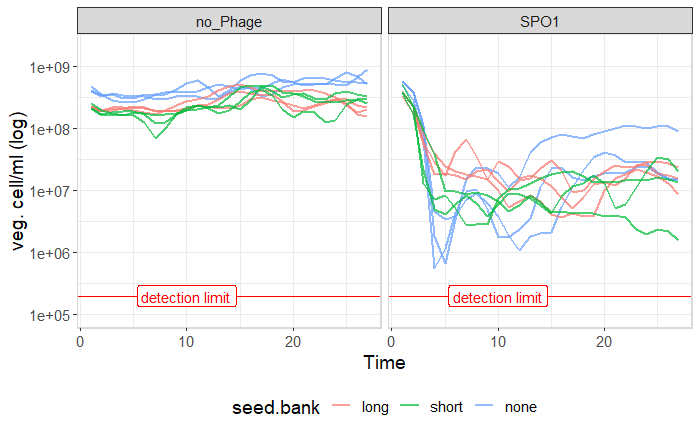

```r
d.4stat%>%
    ggplot(aes(x=Time, y=veg.ml))+
      geom_line(aes(group=flask,color=seed.bank), size=1, alpha=0.7)+
  geom_hline(yintercept = detection.limit, color="red")+
  geom_label(label="detection limit", x=10, y=log10(detection.limit), color="red")+
      facet_wrap(~phage)+
      theme_bw()+
      panel_border()+
      scale_y_log10()+
      theme(legend.position = "bottom",
            text=element_text(size=14))+
      ylab("veg. cell/ml (log)")+
      coord_cartesian(ylim = c(1e5, 2e9))
```

All points usable.

## Model selection

### ARMA covariance

This is a combined auto-regeressive model, AR(p) and moving average model, MA(q). I here take a model selection approach to choose these parameters (lowest AIC).

```r
# initalise empty table
pq.aic <- tibble(p=1, q=1,aic=1)%>%
  filter(p>1)

# Playing around with p&q I found the space in which the model convergence is limited
for(Q in c(0:2)){
  for (P in c(1:(10-2*Q))){

        #this fllowing combination does not work: "iteration limit reached without convergence"
    if(P>=9 & Q==0) next
    if(P>=8 & Q==1) next
    # if(P==1 & Q==2) next
    # if(P==3 & Q==2) next

    cur.model <-
        d.4stat%>%
  # looking only at veg cells (veg.ml)
    lme(veg.ml ~ phage*seed.bank * time.fct , random = ~1|flask,
            correlation = corARMA(form = ~ Time | flask, p=P,q=Q),
            data = .)

    pq.aic <-
      tibble(p=P, q=Q,aic=AIC(cur.model))%>%
      bind_rows(pq.aic,.)

  }
}

pq.aic%>%arrange(aic)
```

| p | q | aic |
| --- | --- | --- |
| 5 | 2 | 12399.34 |
| 6 | 2 | 12401.02 |
| 2 | 2 | 12404.72 |
| 7 | 1 | 12406.26 |
| 3 | 2 | 12406.72 |
| 4 | 2 | 12408.25 |
| 6 | 1 | 12409.24 |
| 5 | 1 | 12413.92 |
| 3 | 1 | 12433.48 |
| 4 | 1 | 12434.42 |

[output cut: 11 more lines]

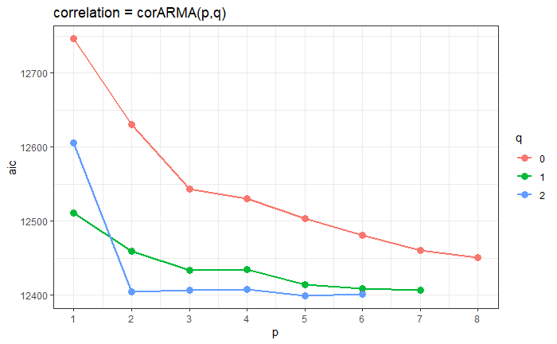

```r
pq.aic%>%
  mutate(q=as.character(q))%>%
  ggplot(aes(p,aic))+
  geom_line(aes(color=q),size=1)+
  geom_point(aes(color=q),size=3)+
  theme_bw()+
  scale_x_continuous(breaks = 1:10)+
  ggtitle("correlation = corARMA(p,q)")
```

```r
NA
NA
```

I will test the best 5 models against AR1,

### compare AR1 with ARMA

```r
l.rm <- list()

pq.best <- pq.aic%>%
  slice_min( order_by=aic,n=5)

for (i in 1:nrow(pq.best)){
  l.rm[[i]] <-
        d.4stat%>%
  # looking only at veg cells (veg.ml)
    lme(veg.ml ~ phage*seed.bank * time.fct , random = ~1|flask,
        correlation = corARMA(form = ~ Time | flask,
                              p=pq.best$p[i],q=pq.best$q[i]),
            data = .)

}


# add corAR1 to list
l.rm[[i+1]] <-
        d.4stat%>%
  # looking only at veg cells (veg.ml)
    lme(veg.ml ~ phage*seed.bank * time.fct , random = ~1|flask,
            correlation = corAR1(form = ~ Time | flask),
            data = .)


# get list order by AIC
aic.l <- sapply(l.rm,AIC)%>%
  sort.list()


# compare models by AIC order
anova.lme(l.rm[[aic.l[6]]],
          l.rm[[aic.l[5]]],
          l.rm[[aic.l[4]]],
          l.rm[[aic.l[3]]],
          l.rm[[aic.l[2]]],
          l.rm[[aic.l[1]]])
```

|  | Model | df | AIC | BIC | logLik | Test | L.Ratio | p-value |
| --- | --- | --- | --- | --- | --- | --- | --- | --- |
| l.rm[[aic.l[6]]] | 1 | 165 | 12746.02 | 13369.84 | -6208.009 |  |  |  |
| l.rm[[aic.l[5]]] | 2 | 169 | 12406.72 | 13045.66 | -6034.359 | 1 vs 2 | 347.3000 | <.0001 |
| l.rm[[aic.l[4]]] | 3 | 172 | 12406.26 | 13056.55 | -6031.132 | 2 vs 3 | 6.4551 | 0.0915 |
| l.rm[[aic.l[3]]] | 4 | 168 | 12404.72 | 13039.88 | -6034.359 | 3 vs 4 | 6.4542 | 0.1677 |
| l.rm[[aic.l[2]]] | 5 | 172 | 12401.02 | 13051.31 | -6028.510 | 4 vs 5 | 11.6968 | 0.0198 |
| l.rm[[aic.l[1]]] | 6 | 171 | 12399.34 | 13045.84 | -6028.668 | 5 vs 6 | 0.3152 | 0.5745 |

```r
#display best model results
getCall(l.rm[[aic.l[6]]])
```

```
lme.formula(fixed = veg.ml ~ phage * seed.bank * time.fct, data = .,
    random = ~1 | flask, correlation = corAR1(form = ~Time |
        flask))
```

```r
  anova.lme(l.rm[[aic.l[6]]])
```

|  | numDF | denDF | F-value | p-value |
| --- | --- | --- | --- | --- |
| (Intercept) | 1 | 312 | 899.8050 | <.0001 |
| phage | 1 | 12 | 317.7085 | <.0001 |
| seed.bank | 2 | 12 | 41.6467 | <.0001 |
| time.fct | 26 | 312 | 14.2484 | <.0001 |
| phage:seed.bank | 2 | 12 | 20.9794 | 0.0001 |
| phage:time.fct | 26 | 312 | 12.6590 | <.0001 |
| seed.bank:time.fct | 52 | 312 | 1.3167 | 0.0823 |
| phage:seed.bank:time.fct | 52 | 312 | 1.0108 | 0.4598 |

**There is significant effect of interaction of phage X seed.bank and phage X time on veg population density, but not 3-way.**

How sensetive would the result be to model selected?

```r
tmp <- map(l.rm, anova.lme)
tmp1 <- map(l.rm, getCall)

for(i in 1:6){
  print(tmp1[[i]])
  if(i<6) print(paste("p=",pq.best$p[i],"q=",pq.best$q[i]))

  print(tmp[[i]])
}
```

```
lme.formula(fixed = veg.ml ~ phage * seed.bank * time.fct, data = .,
    random = ~1 | flask, correlation = corARMA(form = ~Time |
        flask, p = pq.best$p[i], q = pq.best$q[i]))
[1] "p= 5 q= 2"
```

|  | numDF | denDF | F-value | p-value |
| --- | --- | --- | --- | --- |
| (Intercept) | 1 | 312 | 1110.9848 | <.0001 |
| phage | 1 | 12 | 454.0452 | <.0001 |
| seed.bank | 2 | 12 | 50.3578 | <.0001 |
| time.fct | 26 | 312 | 14.9766 | <.0001 |
| phage:seed.bank | 2 | 12 | 26.7956 | <.0001 |
| phage:time.fct | 26 | 312 | 14.7247 | <.0001 |
| seed.bank:time.fct | 52 | 312 | 1.5411 | 0.0141 |
| phage:seed.bank:time.fct | 52 | 312 | 1.3885 | 0.0487 |

```
lme.formula(fixed = veg.ml ~ phage * seed.bank * time.fct, data = .,
    random = ~1 | flask, correlation = corARMA(form = ~Time |
        flask, p = pq.best$p[i], q = pq.best$q[i]))
[1] "p= 6 q= 2"
```

|  | numDF | denDF | F-value | p-value |
| --- | --- | --- | --- | --- |
| (Intercept) | 1 | 312 | 1077.3781 | <.0001 |
| phage | 1 | 12 | 435.9483 | <.0001 |
| seed.bank | 2 | 12 | 48.9663 | <.0001 |
| time.fct | 26 | 312 | 15.2735 | <.0001 |
| phage:seed.bank | 2 | 12 | 26.0308 | <.0001 |
| phage:time.fct | 26 | 312 | 14.6616 | <.0001 |
| seed.bank:time.fct | 52 | 312 | 1.5502 | 0.0131 |
| phage:seed.bank:time.fct | 52 | 312 | 1.3996 | 0.0447 |

```
lme.formula(fixed = veg.ml ~ phage * seed.bank * time.fct, data = .,
    random = ~1 | flask, correlation = corARMA(form = ~Time |
        flask, p = pq.best$p[i], q = pq.best$q[i]))
[1] "p= 2 q= 2"
```

|  | numDF | denDF | F-value | p-value |
| --- | --- | --- | --- | --- |
| (Intercept) | 1 | 312 | 943.0765 | <.0001 |
| phage | 1 | 12 | 448.7135 | <.0001 |
| seed.bank | 2 | 12 | 41.3128 | <.0001 |
| time.fct | 26 | 312 | 13.7224 | <.0001 |
| phage:seed.bank | 2 | 12 | 23.4919 | 0.0001 |
| phage:time.fct | 26 | 312 | 16.1790 | <.0001 |
| seed.bank:time.fct | 52 | 312 | 1.5299 | 0.0155 |
| phage:seed.bank:time.fct | 52 | 312 | 1.3957 | 0.0461 |

```
lme.formula(fixed = veg.ml ~ phage * seed.bank * time.fct, data = .,
    random = ~1 | flask, correlation = corARMA(form = ~Time |
        flask, p = pq.best$p[i], q = pq.best$q[i]))
[1] "p= 7 q= 1"
```

|  | numDF | denDF | F-value | p-value |
| --- | --- | --- | --- | --- |
| (Intercept) | 1 | 312 | 1014.6296 | <.0001 |
| phage | 1 | 12 | 406.9273 | <.0001 |
| seed.bank | 2 | 12 | 46.5517 | <.0001 |
| time.fct | 26 | 312 | 15.9295 | <.0001 |
| phage:seed.bank | 2 | 12 | 24.7551 | 0.0001 |
| phage:time.fct | 26 | 312 | 14.5826 | <.0001 |
| seed.bank:time.fct | 52 | 312 | 1.5402 | 0.0142 |
| phage:seed.bank:time.fct | 52 | 312 | 1.3369 | 0.0713 |

```
lme.formula(fixed = veg.ml ~ phage * seed.bank * time.fct, data = .,
    random = ~1 | flask, correlation = corARMA(form = ~Time |
        flask, p = pq.best$p[i], q = pq.best$q[i]))
[1] "p= 3 q= 2"
```

|  | numDF | denDF | F-value | p-value |
| --- | --- | --- | --- | --- |
| (Intercept) | 1 | 312 | 942.8881 | <.0001 |
| phage | 1 | 12 | 448.6629 | <.0001 |
| seed.bank | 2 | 12 | 41.3039 | <.0001 |
| time.fct | 26 | 312 | 13.7234 | <.0001 |
| phage:seed.bank | 2 | 12 | 23.4875 | 0.0001 |
| phage:time.fct | 26 | 312 | 16.1811 | <.0001 |
| seed.bank:time.fct | 52 | 312 | 1.5300 | 0.0155 |
| phage:seed.bank:time.fct | 52 | 312 | 1.3957 | 0.0461 |

```
lme.formula(fixed = veg.ml ~ phage * seed.bank * time.fct, data = .,
    random = ~1 | flask, correlation = corAR1(form = ~Time |
        flask))
```

|  | numDF | denDF | F-value | p-value |
| --- | --- | --- | --- | --- |
| (Intercept) | 1 | 312 | 899.8050 | <.0001 |
| phage | 1 | 12 | 317.7085 | <.0001 |
| seed.bank | 2 | 12 | 41.6467 | <.0001 |
| time.fct | 26 | 312 | 14.2484 | <.0001 |
| phage:seed.bank | 2 | 12 | 20.9794 | 0.0001 |
| phage:time.fct | 26 | 312 | 12.6590 | <.0001 |
| seed.bank:time.fct | 52 | 312 | 1.3167 | 0.0823 |
| phage:seed.bank:time.fct | 52 | 312 | 1.0108 | 0.4598 |

The other models also have those interactions, ut some also show the 3-way to be significant.